# Взаимодействие дискретных и непрерывных предикторов

## Мы рассмотрим

- Линейные модели c непрерывными и дискретными предикторами
- Взаимодействие дискретных и непрерывных предикторов

## Геометрическая интерпретация коэффициентов регрессии

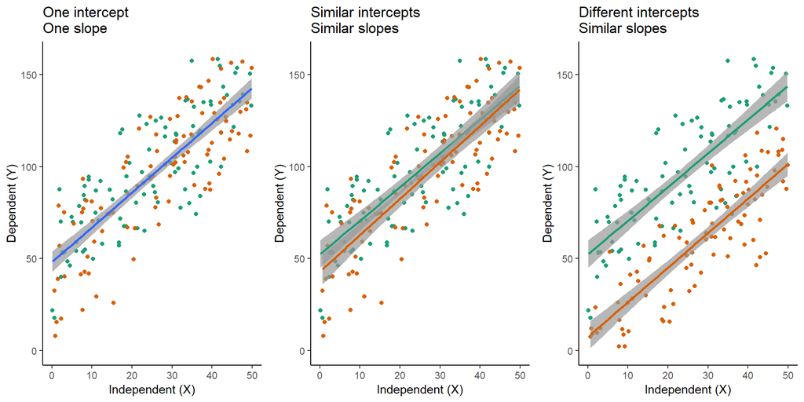

## Но ведь может быть еще и так

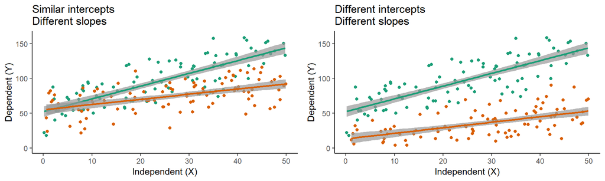

- Как все эти изменения закодировать в уравнении линейной модели?

## Похожий интерсепт, похожий угол наклона

Если зависимости для обеих групп выглядят одинаково, то мы можем пользоваться общей линейной регрессией, не учитывать группу

\(Y = b_0 + b_1X\)

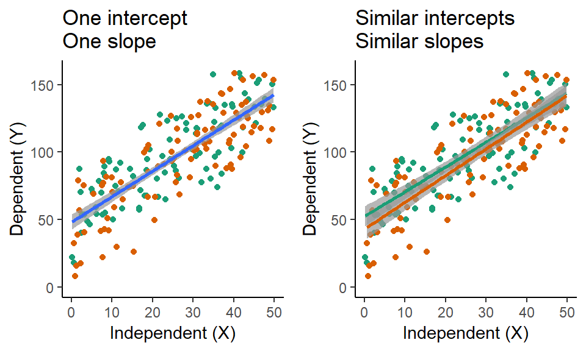

## Разный интерсепт, похожий угол наклона

\(Y = b_0 + b_1X + b_2 I_{Group2}\)

\(I_{Group2} = 1\) если наблюдение из группы 2, и \(I_{Group2} = 0\) в остальных случаях

Уравнение для группы 1: \(Y = b_0 + b_1X + b_2\cdot0\)

Уравнение для группы 2: \(Y = b_0 + b_1X + b_2\cdot1 =(b_0 + b_2) + b_1X\)

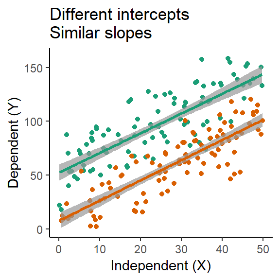

## Похожий интерсепт, разный угол наклона

\(Y = b_0 + b_1X + b_2X\cdot I_{Group2}\)

\(I_{Group2}\) если наблюдение из группы 2, и \(I_{Group2} = 0\) в остальных случаях

Уравнение для группы 1: \(Y = b_0 + b_1X + b_2X \cdot 0 = b_0 + b_1X\)

Уравнение для группы 2: \(Y = b_0 + b_1X + b_2X \cdot 1 = b_0 + (b_1 + b_2)X\)

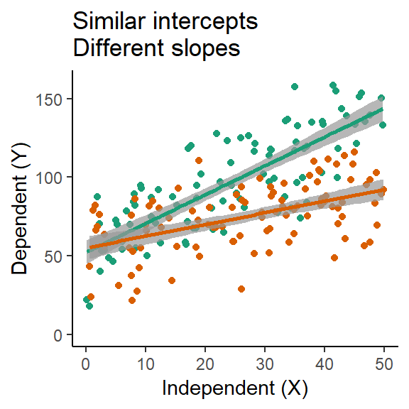

## Разный интерсепт и разный угол наклона

\(Y = b_0 + b_1X + b_2 \cdot I_{Group2} + b_3X \cdot I_{Group2}\)

\(I_{Group2} = 1\) если наблюдение из группы 2, и \(I_{Group2} = 0\) в остальных случаях

Уравнение для группы 1: \(Y = b_0 + b_1X + b_2 \cdot 0 + b_3X \cdot 0 = b_0 + b_1X\)

Уравнение для группы 2: \(Y = b_0 + b_1X + b_2 \cdot 1 + b_3X \cdot 1 = (b_0 + b_2) + (b_1 + b_3)X\)

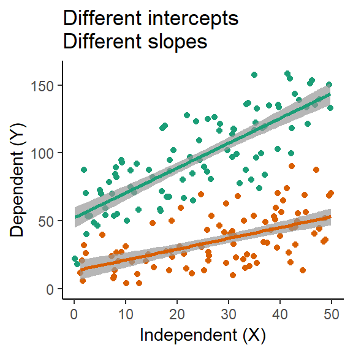

## Физический смысл взаимодействия факторов

Не называйте взаимодействие факторов “корреляцией” или “связью”!

Взаимодействие предикторов означает, что для разных значений одного из факторов зависимость от другого предиктора выглядит по-разному.

Т.е. в данном случае можно сказать: “Для группы 1 и группы 2 зависимость Y от Х выглядит по-разному”

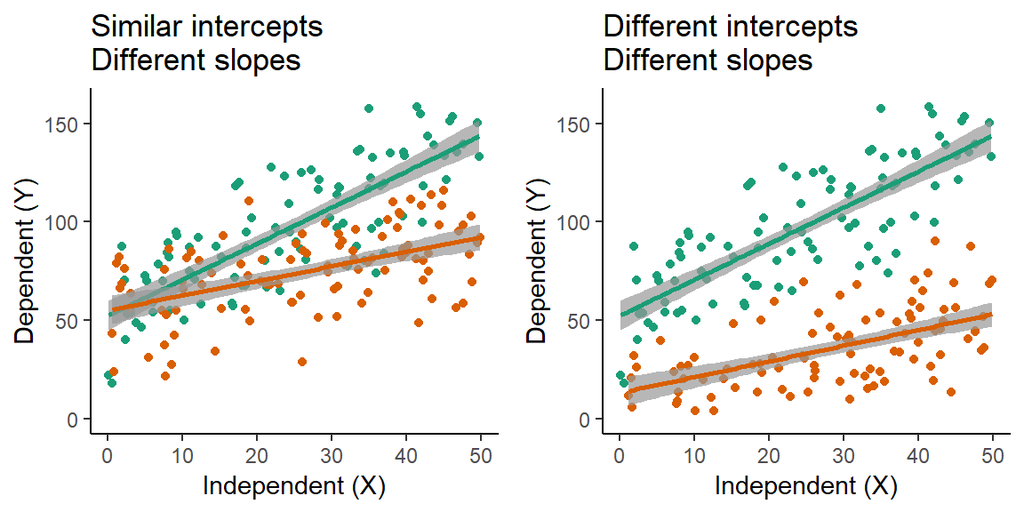

## Если у дискретного предиктора становится больше уровней…

\[y_i = b_0 + b_1x_i + \big(b_2I_{2i} + ... + b_k I_{ki}\big) + \big(b_{k+1}I_{2i}x_i + ... + b_{2k-1} I_{ki} x_i\big) + e_i\]

В случае, **если у дискретного фактора \(k\) градаций**, уравнение полной модели будет включать несколько групп коэффициентов:

- \(b_0\) — значение свободного члена для базового уровня дискретного фактора
- \(b_1\) — коэффициент угла наклона для базового уровня дискретного фактора

Поправки для свободного члена:

- \(b_2, ..., b_k\) — коррекция свободного члена для других уровней (всего их \(k - 1\))

Поправки для угла наклона:

- \(b_{k+1}, ..., b_{2k - 1}\) — коррекция коэффициентов угла наклона для других уровней (всего их \(k - 1\))

## Модель со взаимодействием на примере данных о весе новорожденных

## Вес новорожденных и курение

Как вес новорожденных зависит от возраста матери и того, курит ли она

```r
wt <- read.table("data/birthwt.csv", header = TRUE, sep = ";")
```

## Преобразуем значения перменных

```r
wt$smoke[wt$smoke == 1] <- 'Smoker'
wt$smoke[wt$smoke == 0] <- 'Non smoker'
wt$smoke <- factor(wt$smoke)
```

## Задание

- Исследуйте данные о весе новорожденных
- Постройте модель зависимости веса новорожденных от возраста матери, того курит она или нет и взаимодействия предикторов
- Проверьте условия применимости этой модели
- Упростите модель, если это возможно
- Напишите общее уравнение и отдельные уравнения модели
- Постройте график предсказаний модели

## Решение

```r
str(wt)
```

```
## 'data.frame':    189 obs. of  9 variables:
##  $ age  : int  19 33 20 21 18 21 22 17 29 26 ...
##  $ lwt  : int  182 155 105 108 107 124 118 103 123 113 ...
##  $ race : int  2 3 1 1 1 3 1 3 1 1 ...
##  $ smoke: Factor w/ 2 levels "Non smoker","Smoker": 1 1 2 2 2 1 1 1 2 2 ...
##  $ ptl  : int  0 0 0 0 0 0 0 0 0 0 ...
##  $ ht   : int  0 0 0 0 0 0 0 0 0 0 ...
##  $ ui   : int  1 0 0 1 1 0 0 0 0 0 ...
##  $ ftv  : int  0 3 1 2 0 0 1 1 1 0 ...
##  $ bwt  : int  2523 2551 2557 2594 2600 2622 2637 2637 2663 2665 ...
```

```r
colSums(is.na(wt))
```

```
##   age   lwt  race smoke   ptl    ht    ui   ftv   bwt
##     0     0     0     0     0     0     0     0     0
```

## Решение

```r
table(wt$smoke, wt$age)
```

```
##
##              14 15 16 17 18 19 20 21 22 23 24 25 26 27 28 29 30 31 32
##   Non smoker  2  3  5  7  3  8 10  7  8  9 10 12  3  2  5  4  5  2  4
##   Smoker      1  0  2  5  7  8  8  5  5  4  3  3  5  1  4  3  2  3  2
##
##              33 34 35 36 45
##   Non smoker  2  0  1  2  1
##   Smoker      1  1  1  0  0
```

```r
table(wt$smoke, wt$race)
```

```
##
##               1  2  3
##   Non smoker 44 16 55
##   Smoker     52 10 12
```

```r
table(wt$smoke, wt$ui)
```

```
##
##                0   1
##   Non smoker 100  15
##   Smoker      61  13
```

## Решение

```r
wt$race <- factor(wt$race)
wt$smoke <- factor(wt$smoke)
wt$ptl <- factor(wt$ptl)
wt$ht <- factor(wt$ht)
wt$ui <- factor(wt$ui)
wt$ftv <- factor(wt$ftv)
```

## Решение

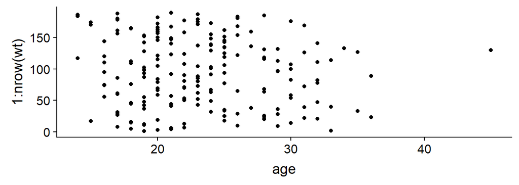

```r
gg_dot <- ggplot(wt, aes(y = 1:nrow(wt))) + geom_point()
gg_dot + aes(x = age)
```

## Решение

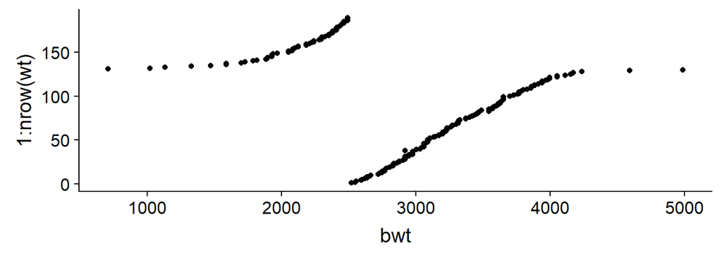

```r
gg_dot + aes(x = bwt)
```

## Решение

### Проверка на колинеарность

```r
wt_mod_1 <- lm(bwt ~ age+smoke, data = wt)
library(car)
vif(wt_mod_1)
```

```
##   age smoke
##     1     1
```

- Колинеарности нет

## Проверка на гомогенность углов наклона

Подберем полную модель.

```r
wt_mod_2 <- lm(bwt ~ age*smoke, data = wt)
drop1(wt_mod_2, test = "F")
```

```
## Single term deletions
##
## Model:
## bwt ~ age * smoke
##           Df Sum of Sq      RSS  AIC F value Pr(>F)
## <none>                 93062605 2485
## age:smoke  1   2609683 95672288 2488    5.19  0.024 *
## ---
## Signif. codes:  0 '***' 0.001 '**' 0.01 '*' 0.05 '.' 0.1 ' ' 1
```

- От исключения взаимодействия модель становится значительно хуже. Оставляем

## Решение

```r
# Данные для графиков остатков
wt_mod_2_diag <- fortify(wt_mod_2)
wt_mod_2_diag <- data.frame(
  wt_mod_2_diag,
  wt[, c("lwt", "race", "smoke", "ptl", "ht", "ui", "ftv")])
```

### График расстояния Кука

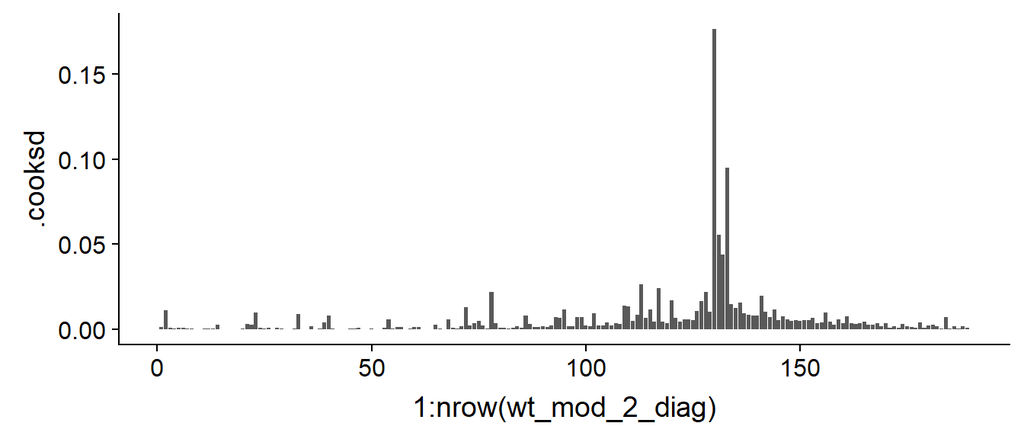

```r
ggplot(wt_mod_2_diag, aes(x = 1:nrow(wt_mod_2_diag), y = .cooksd)) +
  geom_bar(stat = "identity")
```

## Решение

### График остатков от предсказанных значений

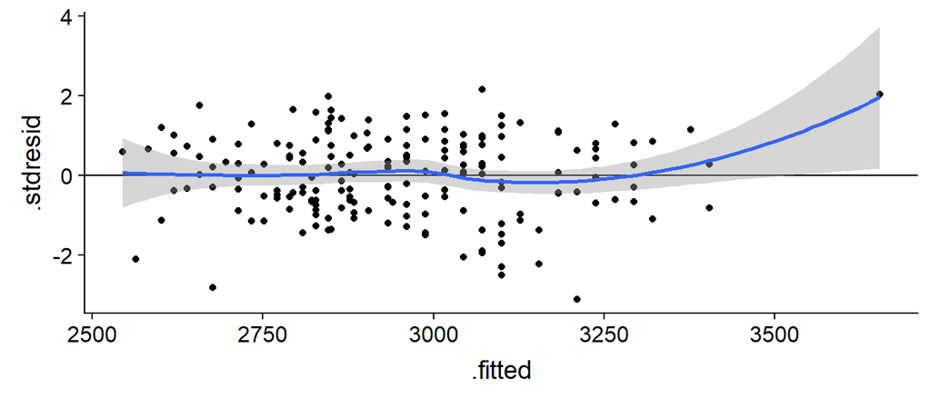

```r
gg_resid <- ggplot(data = wt_mod_2_diag, aes(x = .fitted, y = .stdresid)) +
  geom_point() + geom_hline(yintercept = 0) + geom_smooth()
gg_resid
```

## Решение

### Графики остатков от предикторов в модели и не в модели

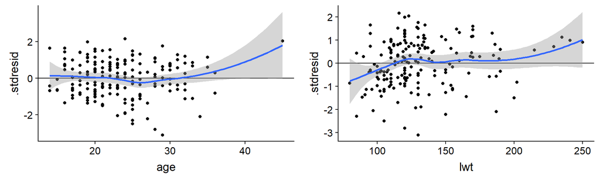

```r
library(gridExtra)
grid.arrange(gg_resid + aes(x = age),
             gg_resid + aes(x = lwt),
             nrow = 1)
```

## Решение

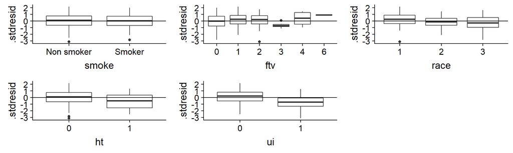

```r
gg_box <- ggplot(data = wt_mod_2_diag, aes(x = smoke, y = .stdresid)) +
  geom_boxplot() + geom_hline(yintercept = 0)

grid.arrange(gg_box + aes(x = smoke),
             gg_box + aes(x = ftv),
             gg_box + aes(x = race),
             gg_box + aes(x = ht),
             gg_box + aes(x = ui),
             nrow = 2)
```

## Решение

### Квантильный график остатков

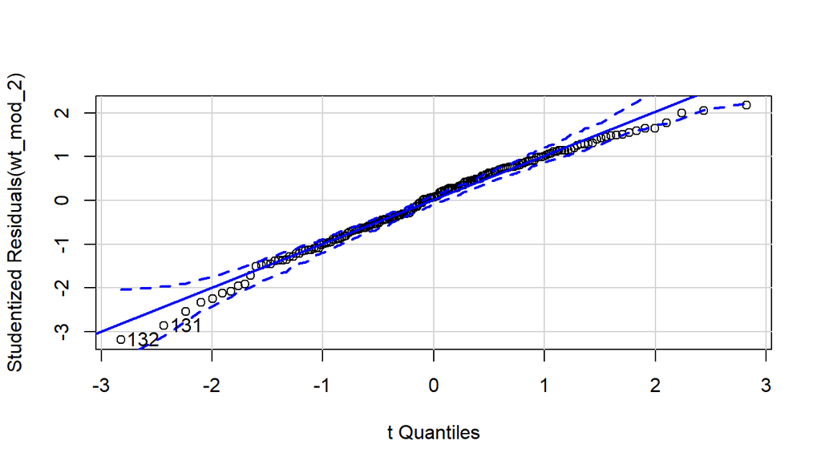

```
## [1] 131 132
```

```r
qqPlot(wt_mod_2)
```

## Проверяем значимость коэффициентов

Подумайте, что означают эти коэффициенты

```r
summary(wt_mod_2)
```

```
##
## Call:
## lm(formula = bwt ~ age * smoke, data = wt)
##
## Residuals:
##     Min      1Q  Median      3Q     Max
## -2189.3  -458.5    51.5   527.3  1521.4
##
## Coefficients:
##                 Estimate Std. Error t value Pr(>|t|)
## (Intercept)       2406.1      292.2    8.23  3.2e-14 ***
## age                 27.7       12.1    2.28    0.024 *
## smokeSmoker        798.2      484.3    1.65    0.101
## age:smokeSmoker    -46.6       20.4   -2.28    0.024 *
## ---
## Signif. codes:  0 '***' 0.001 '**' 0.01 '*' 0.05 '.' 0.1 ' ' 1
##
## Residual standard error: 709 on 185 degrees of freedom
## Multiple R-squared:  0.0691, Adjusted R-squared:  0.054
## F-statistic: 4.58 on 3 and 185 DF,  p-value: 0.00407
```

## Таблица дисперсионного анализа

```r
Anova(wt_mod_2, type = 3)
```

```
## Anova Table (Type III tests)
##
## Response: bwt
##               Sum Sq  Df F value  Pr(>F)
## (Intercept) 34110331   1   67.81 3.2e-14 ***
## age          2620946   1    5.21   0.024 *
## smoke        1366143   1    2.72   0.101
## age:smoke    2609683   1    5.19   0.024 *
## Residuals   93062605 185
## ---
## Signif. codes:  0 '***' 0.001 '**' 0.01 '*' 0.05 '.' 0.1 ' ' 1
```

## Анатомируем модель

## Результаты подбора модели

```r
summary(wt_mod_2)
```

```
##
## Call:
## lm(formula = bwt ~ age * smoke, data = wt)
##
## Residuals:
##     Min      1Q  Median      3Q     Max
## -2189.3  -458.5    51.5   527.3  1521.4
##
## Coefficients:
##                 Estimate Std. Error t value Pr(>|t|)
## (Intercept)       2406.1      292.2    8.23  3.2e-14 ***
## age                 27.7       12.1    2.28    0.024 *
## smokeSmoker        798.2      484.3    1.65    0.101
## age:smokeSmoker    -46.6       20.4   -2.28    0.024 *
## ---
## Signif. codes:  0 '***' 0.001 '**' 0.01 '*' 0.05 '.' 0.1 ' ' 1
##
## Residual standard error: 709 on 185 degrees of freedom
## Multiple R-squared:  0.0691, Adjusted R-squared:  0.054
## F-statistic: 4.58 on 3 and 185 DF,  p-value: 0.00407
```

## Можем ли мы избавиться от взаимодействия?

```r
drop1(wt_mod_2, test = 'F')
```

```
## Single term deletions
##
## Model:
## bwt ~ age * smoke
##           Df Sum of Sq      RSS  AIC F value Pr(>F)
## <none>                 93062605 2485
## age:smoke  1   2609683 95672288 2488    5.19  0.024 *
## ---
## Signif. codes:  0 '***' 0.001 '**' 0.01 '*' 0.05 '.' 0.1 ' ' 1
```

Если удалить взаимодействия, то модель значимо изменится.

В этой системе присутствует взаимодействие!

## Модельная матрица при наличии взаимодействий дискретного и непрерывного предиктора

```r
X <- model.matrix(wt_mod_2)

head(X, 10)
```

```
##    (Intercept) age smokeSmoker age:smokeSmoker
## 1            1  19           0               0
## 2            1  33           0               0
## 3            1  20           1              20
## 4            1  21           1              21
## 5            1  18           1              18
## 6            1  21           0               0
## 7            1  22           0               0
## 8            1  17           0               0
## 9            1  29           1              29
## 10           1  26           1              26
```

В колонке `(Intercept)` — как всегда единицы.

В колонке `age` — возраст матери

Базовый уровень `smoke` = `Non smoker`, в колонке `smokeSmoker` стоят единицы, если мать курящая, если она не курит, то стоят нули.

Колонка `age:smokeSmoker` описывает взаимодействие: если мать курит (`Smoker`), то в этой колонке стоит ее возраст, если мать не курит (`Non smoker`), то стоит ноль.

## Вектор коэффициентов

```r
b <- coefficients(wt_mod_2)
b
```

```
##     (Intercept)             age     smokeSmoker age:smokeSmoker
##       2406.0580         27.7314        798.1749        -46.5719
```

## Предсказанные значения в матричном виде

\[ \widehat{\textbf{y}} = \textbf{X} \textbf{b} \]

```r
as.numeric(fitted(wt_mod_2)[1])
```

```
## [1] 2932.95
```

```r
(X %*% b) [1]
```

```
## [1] 2932.95
```

## Предсказанное значение для объекта, относящегося к базовому уровню

```r
X[1,] # Первая строка в модельной матрице
```

```
##     (Intercept)             age     smokeSmoker age:smokeSmoker
##               1              19               0               0
```

```r
b
```

```
##     (Intercept)             age     smokeSmoker age:smokeSmoker
##       2406.0580         27.7314        798.1749        -46.5719
```

Что происходит при матричном умножении

```r
1 * 2406.0580 + 19.0 * 27.7314  + 0 * 798.1749 + 0 * -46.5719
```

```
## [1] 2932.95
```

## Общий вид формулы предсказанного значения для базового уровня

\[ \widehat{bwt_i} = 2406.0580 + 27.7314 age_i \]

## Предсказанное значение для объекта, не относящегося к базовому уровню

```r
as.numeric(fitted(wt_mod_2)[3])
```

```
## [1] 2827.42
```

```r
X[3,] # Третья строка в модельной матрице
```

```
##     (Intercept)             age     smokeSmoker age:smokeSmoker
##               1              20               1              20
```

```r
b # Коэффциенты
```

```
##     (Intercept)             age     smokeSmoker age:smokeSmoker
##       2406.0580         27.7314        798.1749        -46.5719
```

Что происходит при матричном умножении

```r
1 * 2406.0580 + 20 * 27.7314  + 1 * 798.1749 + 20 * -46.5719
```

```
## [1] 2827.42
```

## Общий вид формулы предсказанного значения для объектов, не относящихся к базовому уровню

\[ \widehat{bwt}_i = 2406.0580 + 27.7314 age_i + 798.1749 + (-46.5719) age_i \]

\[ \widehat{bwt}_i = (2406.0580 + 798.1749) + (27.7314 - 46.5719) age_i = 3204.23 +(-18.8405)age_i \]

## Визуализация модели

## Сложные модели лучше по возможности изображать в виде графика

### Данные для графика

```r
# Диапазон возрастов разный для курящих и некурящих, поэтому...
library(dplyr)
new_data <- wt %>% group_by(smoke)%>%
  do(data.frame(age = seq(min(.$age), max(.$age), length.out = 100)))

# Предсказанные значения
Predictions <- predict(wt_mod_2, newdata = new_data, se.fit = TRUE)
new_data$fit <- Predictions$fit

# Стандартные ошибки
new_data$se <- Predictions$se.fit
# Критические значения t
t_crit <- qt(0.975, df = nrow(wt) - length(coef(wt_mod_2)))
# Доверительный интервал
new_data$upr <- new_data$fit + t_crit * new_data$se
new_data$lwr <- new_data$fit - t_crit * new_data$se
```

## Рисуем график предсказаний

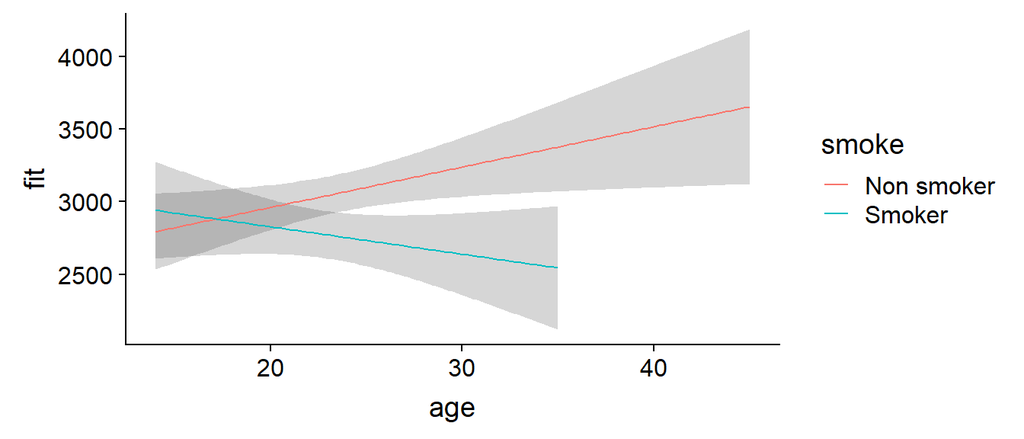

```r
Pl_smoke <- ggplot(new_data, aes(x = age, y = fit)) +
  geom_ribbon(alpha = 0.2, aes(ymin = lwr, ymax = upr, group = smoke)) +
  geom_line(aes(colour = smoke))
Pl_smoke
```

## На графике предсказаний можно показать исходные значения

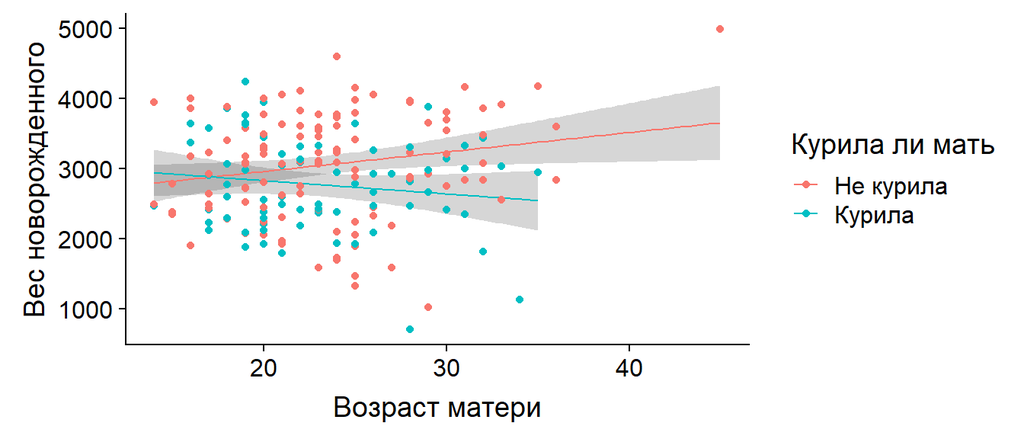

```r
Pl_final <- Pl_smoke +
  geom_point(data = wt, aes(x = age, y = bwt, colour = smoke)) +
  scale_colour_discrete('Курила ли мать', labels = c('Не курила', 'Курила')) +
  labs(x = 'Возраст матери', y = 'Вес новорожденного')
Pl_final
```

## О чем говорят результаты

1. Наличие значимого взаимодействия говорит о том, что связь веса новорожденного и возраста матери выглядит по-разному у курящих и некурящих матерей.
2. Мы не можем судить о влиянии каждого из предикторов по отдельности (main effects), так как они взаимодействуют.
3. При визуализации модели становится видно, что у некурящих матерей есть тенденция с увеличением возраста рожать более крупных детей, у курящих матерей эта связь не выражена.
4. У курящих женщин с возрастом более 25 лет есть тенденция рожать более легких детей.

## Take home messages

- У дискретных и непрерывных факторов могут быть взаимодействия, поэтому анализ нужно начинать с более полной модели (чтобы можно было протестировать и исключить недостоверные взаимодействия)

## Что почитать

- Must read paper! Zuur, A.F. and Ieno, E.N., 2016. A protocol for conducting and presenting results of regression‐type analyses. Methods in Ecology and Evolution, 7(6), pp.636-645.
- Кабаков Р.И. R в действии. Анализ и визуализация данных на языке R. М.: ДМК Пресс, 2014
- Zuur, A., Ieno, E.N. and Smith, G.M., 2007. Analyzing ecological data. Springer Science & Business Media.
- Quinn G.P., Keough M.J. 2002. Experimental design and data analysis for biologists
- Logan M. 2010. Biostatistical Design and Analysis Using R. A Practical Guide